# 200811-study

Nougaga

2020 8 11

## **표본정규분포(Standard Normal Distribution)**

### **중심극한정리**

- 모집단이 정규분포를 따르지 않아도 n이 충분히 크다면 표본평균은 정규분포를 따라감

```r
library(dplyr)
```

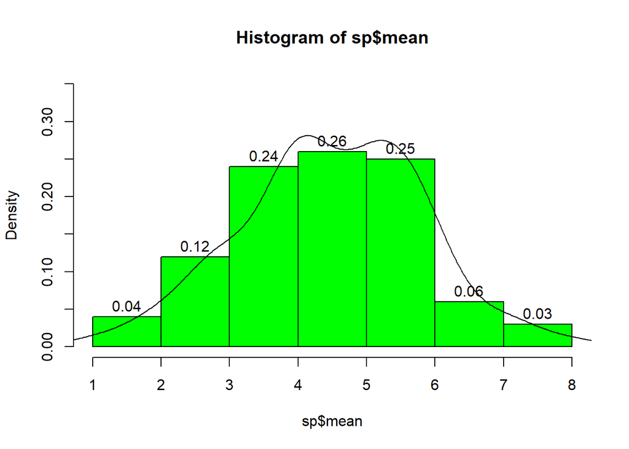

```r
li = seq(0,9,by=1)
sp = c()
sp_sum = c()
sp_mean = c()

for (i in 1:100){
  sp <- append(sp, sample(li, size=5, replace=T))
}

sp <- matrix(sp, ncol=5, byrow=T)
sp <- as.data.frame(sp)
sp <- sp %>% mutate(sum=apply(sp,1,sum))  # sp$sum <- apply(sp,1,sum)
sp <- sp %>% mutate(mean=sum/5)



hist(sp$mean, labels=T, freq=F, ylim=c(0,0.35), col="green");lines(density(sp$mean))
```

#### 대립가설, 귀무가설, p-value, 유의수준 + 대립가설: 증명하고 싶은 가설 + 귀무가설: 대립가설과 반대로 가설, 반증을 찾아서 대립가설을 증명 + p-value: 귀무가설이 사실일 때 현상이 나타날 확률, 설정한 유의수준보다 작으면 귀무가설을 기각

### 1. **가설검정**

#### **1.1. 교차분석**

범주형 자료를 대상으로 두 개 이상의 변수들에 대한 관련성을 알아보기 위해

결합분포를 나타내는 교차분할표를 작성하고 이를 통해 변수 상호 간의 관련성 여부를 분석하는 방법이다.

```r
data <- read.csv("..\\..\\..\\data\\cleanDescriptive.csv", header=T)
dim(data); head(data)
```

```
## [1] 248  14
```

```
##   resident gender age level cost type survey pass cost2 resident2 gender2
## 1        1      1  50     1  5.1    1      1    2     2    특별시    남자
## 2        2      1  54     2  4.2    1      2    2     2    광역시    남자
## 3       NA      1  62     2  4.7    1      1    1     2      <NA>    남자
## 4        4      2  50    NA  3.5    1      4    1    NA    광역시    여자
## 5        5      1  51     1  5.0    1      3    1     2    시구군    남자
## 6        3      1  55     2  5.4    1      3   NA     2    광역시    남자
##     age2 level2 pass2
## 1 장년층   고졸  실패
## 2 장년층   대졸  실패
## 3 노년층   대졸  합격
## 4 장년층   <NA>  합격
## 5 장년층   고졸  합격
## 6 장년층   대졸  <NA>
```

```r
# 변수 리코딩
x <- data$level2  # x = 부모의 학력 수준
y <- data$pass2   # y = 자녀의 대학 진학 여부

result <- data.frame(Level=x, Pass=y)
dim(result); head(result)
```

```
## [1] 248   2
```

```
##   Level Pass
## 1  고졸 실패
## 2  대졸 실패
## 3  대졸 합격
## 4  <NA> 합격
## 5  고졸 합격
## 6  대졸 <NA>
```

```r
library(gmodels)
library(ggplot2)

# 교차분할표 작성
gmodels::CrossTable(result$Level, result$Pass)
```

```
##
##
##    Cell Contents
## |-------------------------|
## |                       N |
## | Chi-square contribution |
## |           N / Row Total |
## |           N / Col Total |
## |         N / Table Total |
## |-------------------------|
##
##
## Total Observations in Table:  225
##
##
##              | result$Pass
## result$Level |      실패 |      합격 | Row Total |
## -------------|-----------|-----------|-----------|
##         고졸 |        40 |        49 |        89 |
##              |     0.544 |     0.363 |           |
##              |     0.449 |     0.551 |     0.396 |
##              |     0.444 |     0.363 |           |
##              |     0.178 |     0.218 |           |
## -------------|-----------|-----------|-----------|
##         대졸 |        27 |        55 |        82 |
##              |     1.026 |     0.684 |           |
##              |     0.329 |     0.671 |     0.364 |
##              |     0.300 |     0.407 |           |
##              |     0.120 |     0.244 |           |
## -------------|-----------|-----------|-----------|
##     대학원졸 |        23 |        31 |        54 |
##              |     0.091 |     0.060 |           |
##              |     0.426 |     0.574 |     0.240 |
##              |     0.256 |     0.230 |           |
##              |     0.102 |     0.138 |           |
## -------------|-----------|-----------|-----------|
## Column Total |        90 |       135 |       225 |
##              |     0.400 |     0.600 |           |
## -------------|-----------|-----------|-----------|
##
##
```

```r
table(result)
```

```
##           Pass
## Level      실패 합격
##   고졸       40   49
##   대졸       27   55
##   대학원졸   23   31
```

#### **1.2. 카이제곱 검정**

- 범주별로 관측빈도와 기대빈도의 차이를 통해 확률 모형이 데이터를 얼마나 잘 설명하는지 검정
- 일원 카이제곱 검정
  - 교차분할표 X이용, 한 개의 변인(집단 or 범주)을 대상으로 검정 수행
  - 관찰도수와 기대도수가 일치하는지 검정 -> 적합도 검정
  - 예) 주사위 게임, 선호도 분석
- 이원 카이제곱검정
  - 교차분할표 O이용, 두 개 이상의 변인을 대상으로
  - 독립성 검정: 한 집단 내에서 두 변인의 관계가 독립인지 검정 -> 귀무가설(H_0) 관계 X
  - 동질성 검정: 두 집단 이상에서 각 범주 간의 비율이 서로 동일한 지를 검정 -> 귀무가설(H_0): 모든 표본들의 비율은 동일하다.

#### **일원 카이제곱 검정**

주사위 게임

- 대립가설: 기대치와 관찰치는 차이가 있다. (p<alpha) 즉, 주사위는 게임에 적합하지 않다.
- 귀무가설: 기대치와 관찰치는 차이가 없다. (p>=alpha)즉, 주사위는 게임에 적합하다.

ex)

| 주사위 눈 | 1 | 2 | 3 | 4 | 5 | 6 |
| --- | --- | --- | --- | --- | --- | --- |
| 관측도수 | 4 | 6 | 17 | 16 | 8 | 9 |
| 기대도수 | 10 | 10 | 10 | 10 | 10 | 10 |

```r
chisq.test(c(4,6,17,16,8,9))
```

```
##
##  Chi-squared test for given probabilities
##
## data:  c(4, 6, 17, 16, 8, 9)
## X-squared = 14.2, df = 5, p-value = 0.01439
```

```r
# p-value = 0.01439 < 0.05이므로 유의수준 0.05에서는 귀무가설을 기각
# => 대립가설 채택(주사위는 게임에 적합하지 않음)
```

#### **이원 카이제곱 검정**

#### 독립성 검정

불러온 데이터에서

- 대립가설(H1): 부모의 학력 수준과 자녀의 대학 진학 여부는 관련성이 있다.
- 귀무가설(H0): 부모의 학력 수준과 자녀의 대학 진학 여부는 관련성이 없다.

```r
data1 <- read.csv("..\\..\\..\\data\\cleanDescriptive.csv", header=T)
str(data1)
```

```
## 'data.frame':    248 obs. of  14 variables:
##  $ resident : int  1 2 NA 4 5 3 2 NA 2 5 ...
##  $ gender   : int  1 1 1 2 1 1 2 1 1 2 ...
##  $ age      : int  50 54 62 50 51 55 56 49 49 49 ...
##  $ level    : int  1 2 2 NA 1 2 1 1 2 NA ...
##  $ cost     : num  5.1 4.2 4.7 3.5 5 5.4 4.1 4.4 4.9 2.3 ...
##  $ type     : int  1 1 1 1 1 1 1 1 1 1 ...
##  $ survey   : int  1 2 1 4 3 3 NA NA 1 2 ...
##  $ pass     : int  2 2 1 1 1 NA 2 2 1 1 ...
##  $ cost2    : int  2 2 2 NA 2 2 2 2 2 1 ...
##  $ resident2: chr  "특별시" "광역시" NA "광역시" ...
##  $ gender2  : chr  "남자" "남자" "남자" "여자" ...
##  $ age2     : chr  "장년층" "장년층" "노년층" "장년층" ...
##  $ level2   : chr  "고졸" "대졸" "대졸" NA ...
##  $ pass2    : chr  "실패" "실패" "합격" "합격" ...
```

```r
x <- data1$level2   # 종속변수(설명변수)
y <- data1$pass2    # 반응변수

CrossTable(x, y, chisq = T)
```

```
##
##
##    Cell Contents
## |-------------------------|
## |                       N |
## | Chi-square contribution |
## |           N / Row Total |
## |           N / Col Total |
## |         N / Table Total |
## |-------------------------|
##
##
## Total Observations in Table:  225
##
##
##              | y
##            x |      실패 |      합격 | Row Total |
## -------------|-----------|-----------|-----------|
##         고졸 |        40 |        49 |        89 |
##              |     0.544 |     0.363 |           |
##              |     0.449 |     0.551 |     0.396 |
##              |     0.444 |     0.363 |           |
##              |     0.178 |     0.218 |           |
## -------------|-----------|-----------|-----------|
##         대졸 |        27 |        55 |        82 |
##              |     1.026 |     0.684 |           |
##              |     0.329 |     0.671 |     0.364 |
##              |     0.300 |     0.407 |           |
##              |     0.120 |     0.244 |           |
## -------------|-----------|-----------|-----------|
##     대학원졸 |        23 |        31 |        54 |
##              |     0.091 |     0.060 |           |
##              |     0.426 |     0.574 |     0.240 |
##              |     0.256 |     0.230 |           |
##              |     0.102 |     0.138 |           |
## -------------|-----------|-----------|-----------|
## Column Total |        90 |       135 |       225 |
##              |     0.400 |     0.600 |           |
## -------------|-----------|-----------|-----------|
##
##
## Statistics for All Table Factors
##
##
## Pearson's Chi-squared test
## ------------------------------------------------------------
## Chi^2 =  2.766951     d.f. =  2     p =  0.2507057
##
##
##
```

### **1. 단일집단 검정**

#### **1.1. 단일집단 비율검정**

단일집단의 비율이 어떤 특정한 값과 같은지 검정하는 방법

데이터 준비 –> 전처리 –> 기술통계 –> binom.test() –> 검정 통계량 분석

```r
data <- read.csv("..\\..\\..\\03stat_!\\one_sample.csv", header=T)
head(data)
```

```
##   no gender survey time
## 1  1      2      1  5.1
## 2  2      2      0  5.2
## 3  3      2      1  4.7
## 4  4      2      1  4.8
## 5  5      2      1  5.0
## 6  6      2      1  5.4
```

```r
x <- data$survey
summary(x)  # 결측치 확인
```

```
##    Min. 1st Qu.  Median    Mean 3rd Qu.    Max.
##  0.0000  1.0000  1.0000  0.9067  1.0000  1.0000
```

```r
length(x)   # 길이(150) 확인
```

```
## [1] 150
```

```r
table(x)    # 0: 불만족(14), 1: 만족(136)
```

```
## x
##   0   1
##  14 136
```

```r
# binom.test(c(136,14), p=0.8)

# 1. 양측검정
binom.test(c(136,14), p=0.8, alternative="two.sided", conf.level=0.95)
```

```
##
##  Exact binomial test
##
## data:  c(136, 14)
## number of successes = 136, number of trials = 150, p-value = 0.0006735
## alternative hypothesis: true probability of success is not equal to 0.8
## 95 percent confidence interval:
##  0.8483615 0.9480298
## sample estimates:
## probability of success
##              0.9066667
```

```r
# 2. 방향성을 갖는 단측가설 검정
binom.test(c(136,14), p=0.8, alternative="greater", conf.level = 0.95)
```

```
##
##  Exact binomial test
##
## data:  c(136, 14)
## number of successes = 136, number of trials = 150, p-value = 0.0003179
## alternative hypothesis: true probability of success is greater than 0.8
## 95 percent confidence interval:
##  0.8579426 1.0000000
## sample estimates:
## probability of success
##              0.9066667
```

```r
# 기존의 만족도 80%보다 높다는 비율검정(단측) 실시
# 유의수준 5% 또는 1%에서 p-value(0.0003179)가 매우 작으므로 귀무가설을 기각
```

#### **1.2. 단일집단 평균검정**

단일집단의 평균이 어떤 특정한 집단의 평균과 차이가 있는지를 검정

- 정규성 검정(shapiro.text())을 실시하여 정규분포이면 t.test()
- 정규분포가 아니라면 wilcox.test()
- shapiro 테스트의 귀무가설은 "데이터가 정규성을 따른다,

<실습> + 국내에서 생산된 노트북 평균 사용시간이 약 5.2h로 파악된 상황에서 A 회사에서 생산된 노트북 평균 사용시간과 차이가 있는지 검정하기 위해 A회사 노트북 150대를 랜덤하게 선정하여 검정을 실시한다.

- H1: 국내에서 생산된 노트북과 A회사에서 생산된 노트북의 평균 사용시간에 차이가 있다.
- H0: 국내에서 생산된 노트북과 A회사에서 생산된 노트북의 평균 사용시간에 차이가 없다.

```r
data <- read.csv("..\\..\\..\\03stat_!\\one_sample.csv", header=T)
str(data); head(data)
```

```
## 'data.frame':    150 obs. of  4 variables:
##  $ no    : int  1 2 3 4 5 6 7 8 9 10 ...
##  $ gender: int  2 2 2 2 2 2 2 2 2 1 ...
##  $ survey: int  1 0 1 1 1 1 1 1 0 1 ...
##  $ time  : num  5.1 5.2 4.7 4.8 5 5.4 NA 5 4.4 4.9 ...
```

```
##   no gender survey time
## 1  1      2      1  5.1
## 2  2      2      0  5.2
## 3  3      2      1  4.7
## 4  4      2      1  4.8
## 5  5      2      1  5.0
## 6  6      2      1  5.4
```

```r
x <= data$time
```

```
##   [1] TRUE TRUE TRUE TRUE TRUE TRUE   NA TRUE TRUE TRUE   NA TRUE   NA TRUE TRUE
##  [16] TRUE   NA TRUE TRUE   NA TRUE TRUE TRUE TRUE TRUE   NA TRUE   NA TRUE TRUE
##  [31]   NA TRUE TRUE TRUE   NA TRUE TRUE   NA TRUE TRUE TRUE   NA TRUE TRUE TRUE
##  [46] TRUE   NA TRUE TRUE   NA TRUE TRUE   NA TRUE   NA TRUE   NA TRUE   NA TRUE
##  [61] TRUE   NA TRUE TRUE TRUE   NA TRUE   NA TRUE   NA TRUE TRUE TRUE   NA TRUE
##  [76] TRUE TRUE   NA   NA TRUE TRUE   NA TRUE   NA TRUE TRUE TRUE TRUE TRUE   NA
##  [91] TRUE TRUE   NA TRUE   NA TRUE TRUE   NA TRUE TRUE TRUE   NA TRUE   NA TRUE
## [106]   NA TRUE TRUE   NA TRUE TRUE TRUE TRUE   NA TRUE   NA   NA TRUE TRUE   NA
## [121] TRUE   NA TRUE   NA TRUE   NA TRUE TRUE TRUE TRUE TRUE TRUE TRUE TRUE TRUE
## [136] TRUE TRUE TRUE TRUE TRUE TRUE TRUE TRUE TRUE TRUE TRUE TRUE TRUE TRUE TRUE
```

```r
# 데이터 분포 확인, 결측치 제거
summary(x)
```

```
##    Min. 1st Qu.  Median    Mean 3rd Qu.    Max.
##  0.0000  1.0000  1.0000  0.9067  1.0000  1.0000
```

```r
mean(x)
```

```
## [1] 0.9066667
```

```r
# 데이터 정제
mean(x, na.rm=T)
```

```
## [1] 0.9066667
```

```r
x1 <- na.omit(x); mean(x1)
```

```
## [1] 0.9066667
```

```r
# 정규분포 검정
shapiro.test(x1)
```

```
##
##  Shapiro-Wilk normality test
##
## data:  x1
## W = 0.32884, p-value < 2.2e-16
```

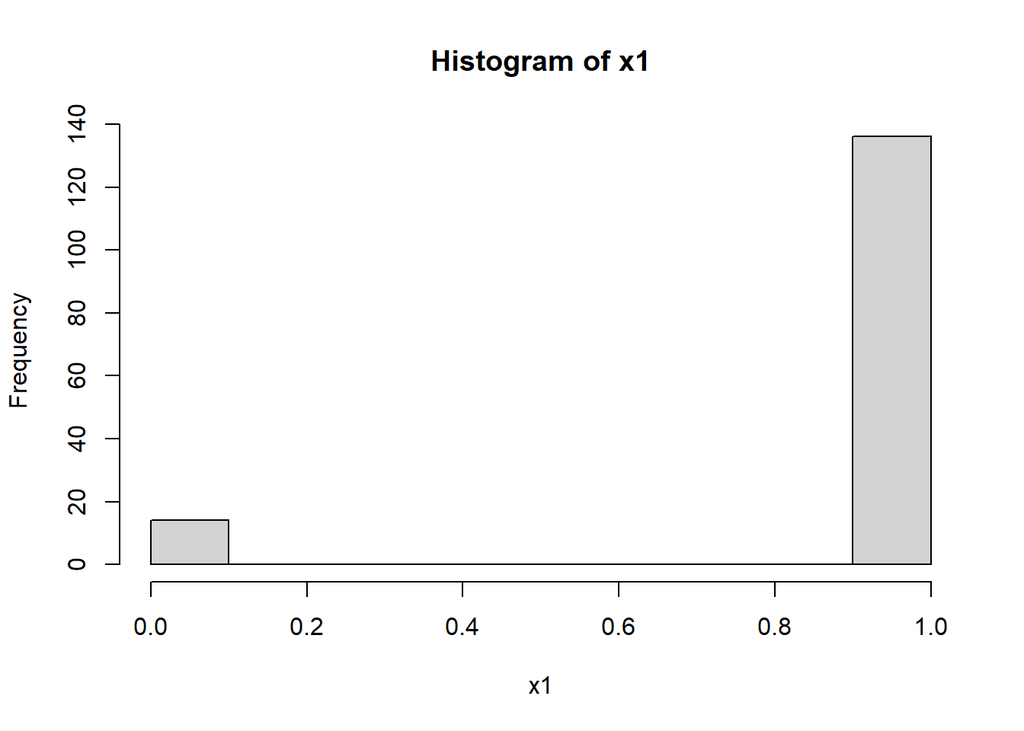

```r
hist(x1)
```

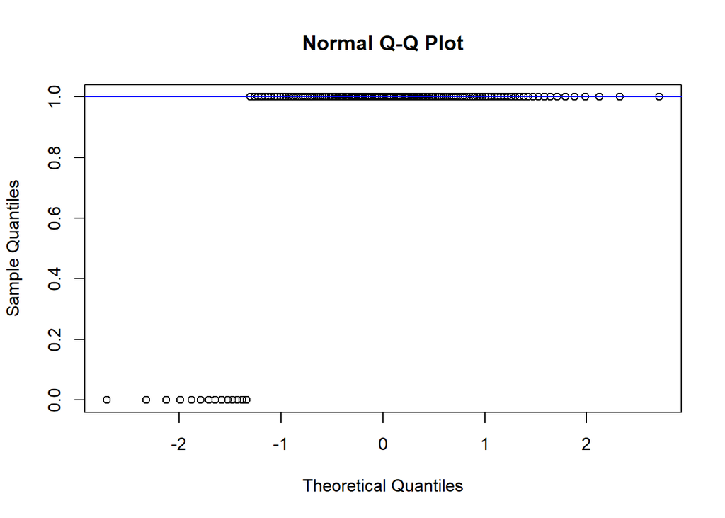

```r
qqnorm(x1)
qqline(x1, lty=1, col="blue")
```

```r
t.test(x1, mu=5.2)
```

```
##
##  One Sample t-test
##
## data:  x1
## t = -180.15, df = 149, p-value < 2.2e-16
## alternative hypothesis: true mean is not equal to 5.2
## 95 percent confidence interval:
##  0.8595756 0.9537578
## sample estimates:
## mean of x
## 0.9066667
```

```r
result <- t.test(x1,mu=5.2, alter="two.sided", conf.level=0.95)
result
```

```
##
##  One Sample t-test
##
## data:  x1
## t = -180.15, df = 149, p-value < 2.2e-16
## alternative hypothesis: true mean is not equal to 5.2
## 95 percent confidence interval:
##  0.8595756 0.9537578
## sample estimates:
## mean of x
## 0.9066667
```

### **2. 두 집단 비율검정**

데이터 분석 –> 전처리 –> 두 집단 suset 생성 -> prop.test"() -> 검정통계량 분석

- H1: 두 가지 교육방법에 따라 교육생의 만족률 차이가 있다.
- H0: 두 가지 교육방법에 따라 교육생의 만족률 차이가 없다.

[output not shown]

```r
data <- data <- read.csv("..\\..\\..\\03stat_!\\two_sample.csv", header=T)

# 두 집단 subset 작성 및 데이터 전처리
x <- data$method  #교육방법(1,2)-> 노이즈 x
y <- data$survey  #만족도(1:만족,0:불만족)

# 집단별 빈도분석
table(x); table(y)
```

```
## x
##   1   2
## 150 150
```

```
## y
##   0   1
##  55 245
```

```r
# 교차분석
table(x,y)
```

```
##    y
## x     0   1
##   1  40 110
##   2  15 135
```

```r
CrossTable(x,y)
```

```
##
##
##    Cell Contents
## |-------------------------|
## |                       N |
## | Chi-square contribution |
## |           N / Row Total |
## |           N / Col Total |
## |         N / Table Total |
## |-------------------------|
##
##
## Total Observations in Table:  300
##
##
##              | y
##            x |         0 |         1 | Row Total |
## -------------|-----------|-----------|-----------|
##            1 |        40 |       110 |       150 |
##              |     5.682 |     1.276 |           |
##              |     0.267 |     0.733 |     0.500 |
##              |     0.727 |     0.449 |           |
##              |     0.133 |     0.367 |           |
## -------------|-----------|-----------|-----------|
##            2 |        15 |       135 |       150 |
##              |     5.682 |     1.276 |           |
##              |     0.100 |     0.900 |     0.500 |
##              |     0.273 |     0.551 |           |
##              |     0.050 |     0.450 |           |
## -------------|-----------|-----------|-----------|
## Column Total |        55 |       245 |       300 |
##              |     0.183 |     0.817 |           |
## -------------|-----------|-----------|-----------|
##
##
```

```r
# 비율검정 1. 양측 검정
prop.test(c(110,135), c(150,150), alternative="two.sided", conf.level=0.95)
```

```
##
##  2-sample test for equality of proportions with continuity correction
##
## data:  c(110, 135) out of c(150, 150)
## X-squared = 12.824, df = 1, p-value = 0.0003422
## alternative hypothesis: two.sided
## 95 percent confidence interval:
##  -0.25884941 -0.07448392
## sample estimates:
##    prop 1    prop 2
## 0.7333333 0.9000000
```

```r
# 비율검정 2. 방향성이 있는 단측설 검정
prop.test(c(110,135), c(150,150), alternative="greater", conf.level=0.95) # p-value가 너무 커서 양측 검정이 나음
```

```
##
##  2-sample test for equality of proportions with continuity correction
##
## data:  c(110, 135) out of c(150, 150)
## X-squared = 12.824, df = 1, p-value = 0.9998
## alternative hypothesis: greater
## 95 percent confidence interval:
##  -0.2451007  1.0000000
## sample estimates:
##    prop 1    prop 2
## 0.7333333 0.9000000
```